# 산점도

- 두 개의 연속형 변수간의 관계를 알아볼 수 있도록 좌표평면 상에 관측점을 찍어 나타낸 그래프
- 좌표평면 상의 관측점은 두 변수를 의미하는 x, y의 점으로 나타냄

산점도 그리기 기본

- plt.scatter(x, y, c, s, alpha)
  - x, y: x축과 y축
  - c: 색
  - s: 마커의 면적
  - alpha: 마커색의 투명도

```python
import sklearn
import pandas as pd
```

**[예제1]** cars93데이터의 length와 weight 변수에 대한 산점도 그리기

```python
import matplotlib.pyplot as plt
import pandas as pd
import numpy as np

cars = pd.read_csv("./data/Cars93.csv")
cars
```

|  | Manufacturer | Model | Type | Min.Price | Price | Max.Price | MPG.city | MPG.highway | AirBags | DriveTrain | ... | Passengers | Length | Wheelbase | Width | Turn.circle | Rear.seat.room | Luggage.room | Weight | Origin | Make |
| --- | --- | --- | --- | --- | --- | --- | --- | --- | --- | --- | --- | --- | --- | --- | --- | --- | --- | --- | --- | --- | --- |
| 0 | Acura | Integra | Small | 12.9 | 15.9 | 18.8 | 25 | 31 | None | Front | ... | 5 | 177 | 102 | 68 | 37 | 26.5 | 11 | 2705 | non-USA | Acura Integra |
| 1 | Acura | Legend | Midsize | 29.2 | 33.9 | 38.7 | 18 | 25 | Driver & Passenger | Front | ... | 5 | 195 | 115 | 71 | 38 | 30.0 | 15 | 3560 | non-USA | Acura Legend |
| 2 | Audi | 90 | Compact | 25.9 | 29.1 | 32.3 | 20 | 26 | Driver only | Front | ... | 5 | 180 | 102 | 67 | 37 | 28.0 | 14 | 3375 | non-USA | Audi 90 |
| 3 | Audi | 100 | Midsize | 30.8 | 37.7 | 44.6 | 19 | 26 | Driver & Passenger | Front | ... | 6 | 193 | 106 | 70 | 37 | 31.0 | 17 | 3405 | non-USA | Audi 100 |
| 4 | BMW | 535i | Midsize | 23.7 | 30.0 | 36.2 | 22 | 30 | Driver only | Rear | ... | 4 | 186 | 109 | 69 | 39 | 27.0 | 13 | 3640 | non-USA | BMW 535i |
| ... | ... | ... | ... | ... | ... | ... | ... | ... | ... | ... | ... | ... | ... | ... | ... | ... | ... | ... | ... | ... | ... |
| 88 | Volkswagen | Eurovan | Van | 16.6 | 19.7 | 22.7 | 17 | 21 | None | Front | ... | 7 | 187 | 115 | 72 | 38 | 34.0 | -2147483648 | 3960 | non-USA | Volkswagen Eurovan |
| 89 | Volkswagen | Passat | Compact | 17.6 | 20.0 | 22.4 | 21 | 30 | None | Front | ... | 5 | 180 | 103 | 67 | 35 | 31.5 | 14 | 2985 | non-USA | Volkswagen Passat |
| 90 | Volkswagen | Corrado | Sporty | 22.9 | 23.3 | 23.7 | 18 | 25 | None | Front | ... | 4 | 159 | 97 | 66 | 36 | 26.0 | 15 | 2810 | non-USA | Volkswagen Corrado |
| 91 | Volvo | 240 | Compact | 21.8 | 22.7 | 23.5 | 21 | 28 | Driver only | Rear | ... | 5 | 190 | 104 | 67 | 37 | 29.5 | 14 | 2985 | non-USA | Volvo 240 |
| 92 | Volvo | 850 | Midsize | 24.8 | 26.7 | 28.5 | 20 | 28 | Driver & Passenger | Front | ... | 5 | 184 | 105 | 69 | 38 | 30.0 | 15 | 3245 | non-USA | Volvo 850 |

93 rows × 27 columns

```python
cars[['Length','Weight']]
```

|  | Length | Weight |
| --- | --- | --- |
| 0 | 177 | 2705 |
| 1 | 195 | 3560 |
| 2 | 180 | 3375 |
| 3 | 193 | 3405 |
| 4 | 186 | 3640 |
| ... | ... | ... |
| 88 | 187 | 3960 |
| 89 | 180 | 2985 |
| 90 | 159 | 2810 |
| 91 | 190 | 2985 |
| 92 | 184 | 3245 |

93 rows × 2 columns

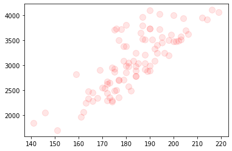

```python
plt.scatter(x=cars['Length'],y=cars['Weight'],c='r',s=100,alpha=0.1)
plt.show()
```

## 산점도 함수 옵션

### 축이름, 그래프 제목

- plt.xlabel('x축 이름')
- plt.ylabel('y축 이름')
- plt.title('그래프 제목', fontdict, loc, pad)
  - fontdict 은 딕셔너리 형태로 폰트에 대한 설정을 입력함
    - fontsize 는 숫자 단위를 입력하거나 'samller', 'x-large' 등의 상대적인 설정 가능
    - fontwegiht 는 'normal', 'bold', 'heavy', 'light', 'ultrabold', 'ultralight' 설정 가능
  - loc 는 위치. 'left', 'center', 'right' 중 선택 가능
  - pad 는 타이틀과 그래프와의 간격 (오프셋)을 포인트 단위로 설정

**[예제]** Cars93의 Length와 Weight 변수에 대한 산점도에 제목과 축 이름을 지정하기

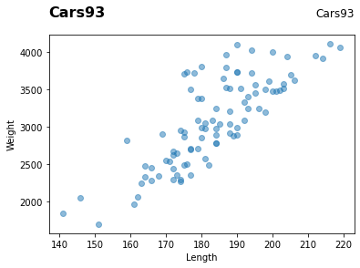

```python
plt.title('Cars93', loc = 'right', pad = 20) # 오른쪽 위

title_font = {
    'fontsize':16,
    'fontweight': 'bold'
}

plt.scatter(x=cars['Length'], y=cars['Weight'], alpha=0.5)
plt.xlabel('Length')
plt.ylabel('Weight')
plt.title('Cars93', fontdict = title_font, loc = 'left', pad=20) ## 왼쪽 위 타이틀
plt.show()
```

## 좌표축 범위

- plt.axis([xmin, xmax, ymin, ymax])
- 입력값이 없으면 데이터에 맞게 자동으로 범위를 지정해줌

**[예제]** Cars93의 Length와 Weight 변수에 대해 각각 최솟값, 최댓값을 구하고 적절한 축 범위를 지정하여 산점도 그리기

```python
a, b = cars['Length'].min(), cars['Length'].max()
print("Length 최솟값: %d, 최댓값: %d" %(a,b))
print('\n')

c, d = cars['Weight'].min(), cars['Weight'].max()
print("Weight 최솟값: %d, 최댓값: %d" %(c,d))
```

```
Length 최솟값: 141, 최댓값: 219


Weight 최솟값: 1695, 최댓값: 4105
```

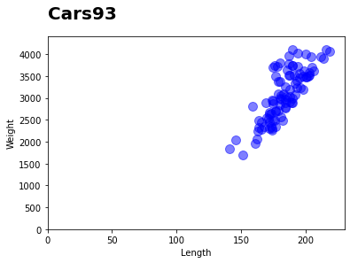

```python
# x축과 y축 범위를 지정하여 산점도 그리기

plt.scatter(x=cars['Length'], y=cars['Weight'], c='b', s=100, alpha=0.5)
plt.axis([0,230,0,4400])

title_font={
    'fontsize':20,
    'fontweight':'bold'
}

plt.xlabel('Length')
plt.ylabel('Weight')
plt.title('Cars93', fontdict = title_font, loc='left', pad=20)
plt.show()
```

## 산점도 활용

```
범주형 변수를 표현할 때에는 seanborn 을 쓰자!
```

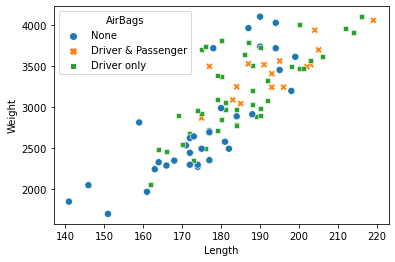

```python
# 범주별로 색과 스타일을 구분하기
import seaborn as sns

sns.scatterplot(x='Length',
               y='Weight',
               hue='AirBags',
               style='AirBags',
               s=50,
               data=cars)
plt.show()
```

```python
cars['AirBags'].value_counts()
```

```
Driver only           43
None                  34
Driver & Passenger    16
Name: AirBags, dtype: int64
```

```python
iris = pd.read_csv('./data/iris.csv')
iris
```

|  | sepal length | sepal width | petal length | petal width | target |
| --- | --- | --- | --- | --- | --- |
| 0 | 5.1 | 3.5 | 1.4 | 0.2 | Iris-setosa |
| 1 | 4.9 | 3.0 | 1.4 | 0.2 | Iris-setosa |
| 2 | 4.7 | 3.2 | 1.3 | 0.2 | Iris-setosa |
| 3 | 4.6 | 3.1 | 1.5 | 0.2 | Iris-setosa |
| 4 | 5.0 | 3.6 | 1.4 | 0.2 | Iris-setosa |
| ... | ... | ... | ... | ... | ... |
| 145 | 6.7 | 3.0 | 5.2 | 2.3 | Iris-virginica |
| 146 | 6.3 | 2.5 | 5.0 | 1.9 | Iris-virginica |
| 147 | 6.5 | 3.0 | 5.2 | 2.0 | Iris-virginica |
| 148 | 6.2 | 3.4 | 5.4 | 2.3 | Iris-virginica |
| 149 | 5.9 | 3.0 | 5.1 | 1.8 | Iris-virginica |

150 rows × 5 columns

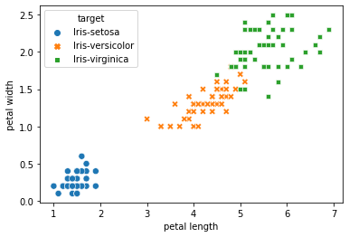

```python
sns.scatterplot(x='petal length',
               y= 'petal width',
               hue='target', #범주별로 색을 다르게 지정
               style='target', #범주별로 스타일을 다르게 지정
               s=50,
               data=iris)
```

## 선 그래프

```python
import matplotlib.pyplot as plt
import pandas as pd
import numpy as np
```

### 선 종류

| 문자 | 설명 |
| --- | --- |
| '-' | 실선 |
| '--' | dash 선 |
| '-.' | dash-dot 선 |
| '.', ':' | 점선 |

```python
x = np.linspace(0,10,11)
```

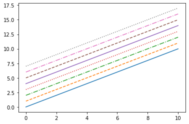

```python
fig = plt.figure()
ax = plt.axes()

plt.plot(x, x+0, linestyle='solid')
plt.plot(x, x+1, linestyle='dashed')
plt.plot(x, x+2, linestyle='dashdot')
plt.plot(x, x+3, linestyle='dotted')

# For short, you can use the following codes
plt.plot(x, x+4, linestyle='-')
plt.plot(x, x+5, linestyle='--')
plt.plot(x, x+6, linestyle='-.')
plt.plot(x, x+7, linestyle=':')
```

## 직선 그래프

y = ax + b 형태의 직선이나 y=h 형태의 가로선 혹은 x=v 형태의 세로선

> plt.plot(x축, 회귀식, data=데이터, c='color') # y = ax + b 형태의 직선  
> plt.hlines(y, xmin, xmax) # y = h 형태의 수평선  
> plt.vlines(x, ymin, ymax) # x = v 형태의 수직선

**[예제]**

fifa 데이터에서 passing과 overall 사이의 선형회귀모형을 생성한 뒤, 직선 그래프로 표현하기

선형 회귀식에 대한 그래프는 passing과 overall에 대한 산점도 위에 나타내며, 색상은 빨강으로 지정하여 표현

overall의 중위수는 수평선, passing의 중위수는 수직선으로 그리도 각각의 선은 점 스타일의 회색 선으로 지정

```python
fifa = pd.read_csv("./data/players_20.csv")
feature = ['sofifa_id','short_name','passing','overall']
fifa = fifa[feature].head(100)
fifa.dropna(inplace=True)
fifa.head()
```

|  | sofifa_id | short_name | passing | overall |
| --- | --- | --- | --- | --- |
| 0 | 158023 | L. Messi | 92.0 | 94 |
| 1 | 20801 | Cristiano Ronaldo | 82.0 | 93 |
| 2 | 190871 | Neymar Jr | 87.0 | 92 |
| 4 | 183277 | E. Hazard | 86.0 | 91 |
| 5 | 192985 | K. De Bruyne | 92.0 | 91 |

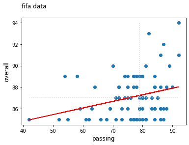

```python
from sklearn.linear_model import LinearRegression

lr = LinearRegression()
x = fifa[['passing']]
lr.fit(x, fifa['overall'])

plt.scatter(fifa['passing'], fifa['overall'])
plt.plot(fifa['passing'], lr.predict(x), c='r', linestyle='-')
plt.hlines(np.median(fifa['overall']), np.min(fifa['passing']), np.max(fifa['passing']), 'lightgrey', linestyle=':')
plt.vlines(np.median(fifa['passing']), np.min(fifa['overall']), np.max(fifa['overall']), 'lightgrey', linestyle=':')

plt.xlabel('passing', fontsize=12)
plt.ylabel('overall', fontsize=12)
plt.title('fifa data', loc='left', pad=20)
plt.show()
```

### 곡선 그래프

**[예제]**

평균이 0이고 표준편차가 1인 확률밀도함수를 생성하고 그래프로 나타내기

x축의 범위는 -3 ~ +3으로 한다

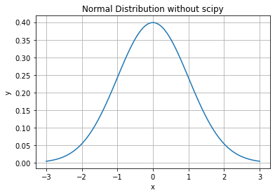

```python
import scipy.stats as stats

x = np.linspace(-3,3,100)

y = stats.norm(0,1).pdf(x)

plt.plot(x,y)
plt.xlabel('x')
plt.ylabel('y')
plt.grid()
plt.title('Normal Distribution without scipy')
plt.show()
```

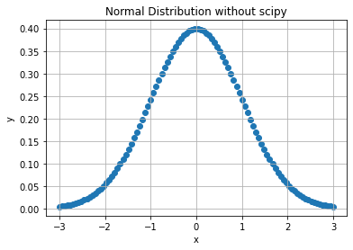

```python
import scipy.stats as stats

x = np.linspace(-3,3,100)

y = stats.norm(0,1).pdf(x)

plt.scatter(x,y)
plt.xlabel('x')
plt.ylabel('y')
plt.grid()
plt.title('Normal Distribution without scipy')
plt.show()
```

### 꺾은선 그래프

여러 범주에 대한 관측값을 비교하거나 시간의 흐름에 따른 데이터에서 추세를 파악하기 위해 사용

**X축은 정렬되어 있어야함**

> plt.plot(x축, y축, data=데이터, ls='-/--/-./:', lw=int_value, c='color') # ls: 선 스타일, lw: 선 굵기  
> plt.legend(['항목 이름1', '항목 이름2'])

**[예시]** Car93에서 Wheelbase 따른 Type 별 Pirce의 관측값을 살펴보자

```python
cars = pd.read_csv('./data/Cars93.csv')
cars.head()
```

|  | Manufacturer | Model | Type | Min.Price | Price | Max.Price | MPG.city | MPG.highway | AirBags | DriveTrain | ... | Passengers | Length | Wheelbase | Width | Turn.circle | Rear.seat.room | Luggage.room | Weight | Origin | Make |
| --- | --- | --- | --- | --- | --- | --- | --- | --- | --- | --- | --- | --- | --- | --- | --- | --- | --- | --- | --- | --- | --- |
| 0 | Acura | Integra | Small | 12.9 | 15.9 | 18.8 | 25 | 31 | None | Front | ... | 5 | 177 | 102 | 68 | 37 | 26.5 | 11 | 2705 | non-USA | Acura Integra |
| 1 | Acura | Legend | Midsize | 29.2 | 33.9 | 38.7 | 18 | 25 | Driver & Passenger | Front | ... | 5 | 195 | 115 | 71 | 38 | 30.0 | 15 | 3560 | non-USA | Acura Legend |
| 2 | Audi | 90 | Compact | 25.9 | 29.1 | 32.3 | 20 | 26 | Driver only | Front | ... | 5 | 180 | 102 | 67 | 37 | 28.0 | 14 | 3375 | non-USA | Audi 90 |
| 3 | Audi | 100 | Midsize | 30.8 | 37.7 | 44.6 | 19 | 26 | Driver & Passenger | Front | ... | 6 | 193 | 106 | 70 | 37 | 31.0 | 17 | 3405 | non-USA | Audi 100 |
| 4 | BMW | 535i | Midsize | 23.7 | 30.0 | 36.2 | 22 | 30 | Driver only | Rear | ... | 4 | 186 | 109 | 69 | 39 | 27.0 | 13 | 3640 | non-USA | BMW 535i |

5 rows × 27 columns

```python
cars.Wheelbase.value_counts()
```

```
103    9
97     7
98     6
105    5
101    5
110    5
113    5
104    5
111    5
102    4
99     3
96     3
93     3
106    3
108    3
94     3
115    2
112    2
114    2
116    2
90     2
109    2
107    2
100    2
95     1
117    1
119    1
Name: Wheelbase, dtype: int64
```

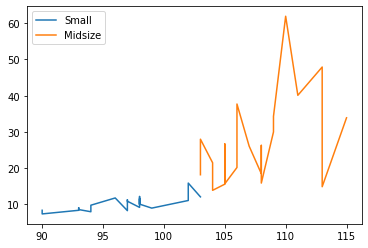

```python
# 선형 그래프를 그릴 때에는 X축 정렬을 해줘야 함

car_type = cars.Type.unique()
car_sorted = cars.sort_values(by=['Wheelbase'])

plt.plot('Wheelbase', 'Price', data=car_sorted.loc[car_sorted['Type'] == 'Small'])
plt.plot('Wheelbase', 'Price', data=car_sorted.loc[car_sorted['Type'] == 'Midsize'])

plt.legend(car_type)
plt.show()
```

### 막대 그래프

pyplot 의 bar() 함수를 사용하여 막대 그래프를 그릴 수 있음

> plt.bar(x, height, width=0.8, bottom=None, align='center', data=None, color='black', edgecolor='black')

> 수평으로 표현 된 막대 그래프는 barh() 함수로 그린다. plt.barh(x, height, width=0.8, bottom=None, align='center', data=None, color='black', edgecolor='black')

**[예제]**

fifa20 데이터의 overall 변수는 선수의 능력치를 나타낸다.  
preferred_foot 변수는 선호하는 발을 의미하며, 총 2개의 범주로 이루어져 있다.  
두 범주형 변수의 각 레벨에 속하는 데이터의 개수를 막대 그래프로 나타내어라.

```python
import pandas as pd
import numpy as np
import matplotlib.pyplot as plt

fifa20 = pd.read_csv('./data/players_20.csv')
fifa20 = fifa20.head(1000)
```

```python
overall_cnt = fifa20['overall'].value_counts()
preferred_foot_cnt = fifa20['preferred_foot'].value_counts()
```

```python
overall_cnt
```

```
78    239
79    185
80    157
82     92
81     82
83     80
84     49
85     35
86     18
88     17
87     15
89     13
77      8
90      4
91      3
92      1
93      1
94      1
Name: overall, dtype: int64
```

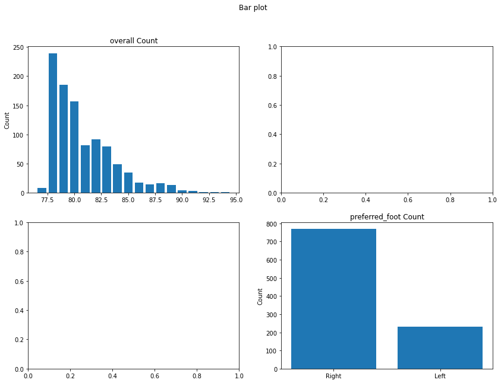

```python
# 두 개의 플롯을 그려야 하므로 두 개의 서브플롯을 선언
# fig는 플롯이 나타날 전체 figure, axs[n]은 번째 서브 플롯을 나타냄

fig, axs = plt.subplots(2,2, figsize = (14,10))
fig.suptitle('Bar plot')

axs[0][0].bar(overall_cnt.index, overall_cnt.values)
axs[0][0].set_title('overall Count')
axs[0][0].set_ylabel('Count')

axs[1][1].bar(preferred_foot_cnt.index, preferred_foot_cnt.values)
axs[1][1].set_title('preferred_foot Count')
axs[1][1].set_ylabel('Count')

plt.show()
```

**[예제]** 여러 개의 범주형 변수를 막대 그래프에 표현하기

fifa20 데이터의 overall preferred_foot 변수의 범주별 데이터 개수를 막대 그래프로 한 번에 표현하고 범례를 함께 나타내기

```python
table = pd.crosstab(fifa20['overall'], fifa20['preferred_foot'])
table
```

| preferred_foot overall | Left | Right |
| --- | --- | --- |
| 77 | 1 | 7 |
| 78 | 51 | 188 |
| 79 | 42 | 143 |
| 80 | 33 | 124 |
| 81 | 21 | 61 |
| 82 | 20 | 72 |
| 83 | 24 | 56 |
| 84 | 11 | 38 |
| 85 | 13 | 22 |
| 86 | 3 | 15 |
| 87 | 4 | 11 |
| 88 | 5 | 12 |
| 89 | 2 | 11 |
| 90 | 1 | 3 |
| 91 | 0 | 3 |
| 92 | 0 | 1 |
| 93 | 0 | 1 |
| 94 | 1 | 0 |

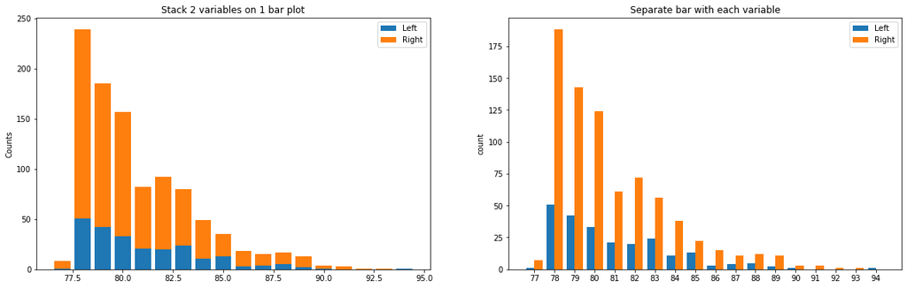

```python
fig, axs = plt.subplots(1,2, figsize = (20,6))
width = 0.4

# 2 개의 서브 플롯을 선언하고 그 중 하나에서 bottom 인수를 사용하여 다른 값 아래에 위치하게 함

axs[0].bar(table['Left'].index, table['Left'].values, label='Left')
axs[0].bar(table['Right'].index, table['Right'].values, bottom = table['Left'], label='Right')

axs[0].set_ylabel('Counts')
axs[0].set_title('Stack 2 variables on 1 bar plot')
axs[0].legend()

# 범주의 개수 (ind)를 세어 플롯의 x 인자에 임시 할당하고 x 인자에서 두께를 감산
# 각 bar plot에 두께를 지정

idx = list(table['Right'].index)
ind = np.arange(1, len(idx)+1)

axs[1].bar(ind - width/2, table['Left'].values, width, label='Left')
axs[1].bar(ind + width/2, table['Right'].values, width, label='Right')
axs[1].set_xticks(ind) # set_xticklabels 호출 이전에 선행해서 호출이 되어야야 함 (눈금 고정)
axs[1].set_xticklabels(idx)
axs[1].set_ylabel('count')
axs[1].set_title('Separate bar with each variable')
axs[1].legend()

plt.show()
```

### 히스토그램

도수별 분포를 나타내는 도수분포표를 그래프로 그린 것

```
막대 그래프: **범주형**으로 구분된 변수의 범주별 데이터 수를 구한 것
범주의 순서를 의도에 따라 변경 가능

히스토그램: **연속된 수**를 일정한 구간으로 나눈 후 구간별 데이터의 분포를 그래프로 표현한 것
임의의 범주의 순서를 바꿀 수 없음
```

> plt.hist(x, bins=None, range=None, density=False, color=None, data=None)

> bins: 히스토그램의 구간의 개수 정의 range: bin의 상한값과 하한값 (x.min(), x.max()) 형태로 선언 density: True이면 확률밀도함수를 그리고 반환

**[예제]** fifa20 데이터의 wage_eur 변수에 대해 막대 구간의 개수를 지정하지 않은 히스토그램과 구간의 개수를 5로 지정한 히스토그램 그리기

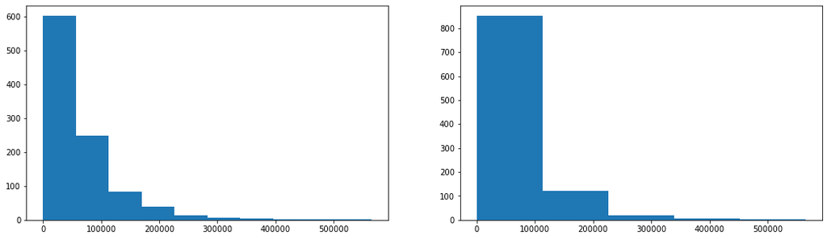

```python
fig, axs = plt.subplots(1,2,figsize=(18,5))

axs[0].hist('wage_eur',data=fifa20)
axs[1].hist('wage_eur',bins=5, data=fifa20)
```

```python
fifa20[['preferred_foot','height_cm','weight_kg','overall']]
```

|  | preferred_foot | height_cm | weight_kg | overall |
| --- | --- | --- | --- | --- |
| 0 | Left | 170 | 72 | 94 |
| 1 | Right | 187 | 83 | 93 |
| 2 | Right | 175 | 68 | 92 |
| 3 | Right | 188 | 87 | 91 |
| 4 | Right | 175 | 74 | 91 |
| ... | ... | ... | ... | ... |
| 995 | Right | 177 | 66 | 77 |
| 996 | Right | 191 | 86 | 77 |
| 997 | Right | 183 | 78 | 77 |
| 998 | Left | 183 | 62 | 77 |
| 999 | Right | 168 | 66 | 77 |

1000 rows × 4 columns

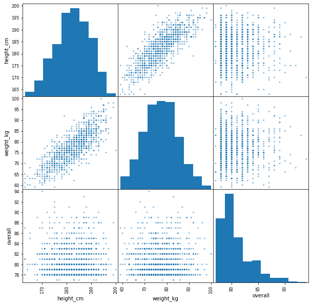

```python
from pandas.plotting import scatter_matrix

scatter_matrix(fifa20[['preferred_foot','height_cm','weight_kg','overall']], alpha=0.5, figsize=(10,10), diagonal='hist')
plt.show()
```

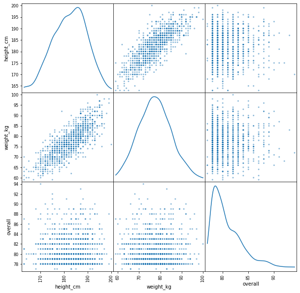

```python
from pandas.plotting import scatter_matrix

scatter_matrix(fifa20[['preferred_foot','height_cm','weight_kg','overall']], alpha=0.5, figsize=(10,10), diagonal='kde')
plt.show()
```

## 상관관계 시각화(히트맵)

- 두 변수 간의 관계의 정도
- 두 확률변수가 함께 변화하는지의 정도를 측정하는 값
  - 단점: 측정 단위 크기를 반영하지 못해 절대적인 상관성의 정도를 파악하기 어려움
  - 단점 극복: 공분산을 두 변수의 표준편차 곱으로 나누어 표준화시킴 (=상관계수)

### 상관분석의 유형

가. 피어슨 상관계수

- 두 연속형 자료가 모두 정규성을 따른다는 가정
- 선형적 상관관계를 측정
- -1 부터 1 사이의 값

| 상황 | 함수 |
| --- | --- |
| 판다스 사용 시 | corr(method = 'pearson') |
| 싸이파이 사용 시 | stats.pearsonr(df1,df2) |

나. 스피어만 상관계수

- 두 변수가 정규성을 만족하지 않거나, 변수가 **순위 및 순서** 형태로 주어지는 경우
- 비모수적 방법 (데이터에 순위를 매긴 후 그 **순위**에 대한 상관계수를 산출함. 실제값 이용 X)
- -1 부터 1 사이의 값
- 비선형관계의 연관성 팡가 가능
- 연속형, 이산형, 순서형 자료에 적용 가능

| 상황 | 함수 |
| --- | --- |
| 판다스 사용 시 | corr(method = 'spearmna') |
| 싸이파이 사용 시 | stats.spearmanr(df1,df2) |

다. 켄달의 순위상관계수

- 데이터가 **순서쌍(Xi, Yi)**로 주어졌을 때
  - Xi가 커짐에 따라 Yi도 커질 경우: 부합
  - Xi가 커짐에 따라 Yi가 작아질 경우: 비부합
- 전체 데이터에서 비부합성에 댛나 부합쌍의 비율로 상관계수를 산출함
- -1부터 1사이의 값
  - 순위상관계수가 1일 경우: 부합쌍의 비율이 100%
  - 순위상관계수가 -1일 경우: 비부합쌍의 비율이 100%
  - 순위상관계수가 0일 경우: 두 변수 X와 Y는 상관성이 없음

| 상황 | 함수 |
| --- | --- |
| 판다스 사용 시 | corr(method = 'kendall') |
| 싸이파이 사용 시 | stats.dendalltau(df1,df2) |

**[예제1]** air 데이터 내의 네 가지 변수 조합별 피어슨 상관계수 그래프 그리기

```python
import pandas as pd
import matplotlib.pyplot as plt
import seaborn as sns
```

```python
air = pd.read_csv('./data/airquality.csv')
air
```

|  | Ozone | Solar.R | Wind | Temp | Month | Day |
| --- | --- | --- | --- | --- | --- | --- |
| 0 | 41.0 | 190.0 | 7.4 | 67 | 5 | 1 |
| 1 | 36.0 | 118.0 | 8.0 | 72 | 5 | 2 |
| 2 | 12.0 | 149.0 | 12.6 | 74 | 5 | 3 |
| 3 | 18.0 | 313.0 | 11.5 | 62 | 5 | 4 |
| 4 | NaN | NaN | 14.3 | 56 | 5 | 5 |
| ... | ... | ... | ... | ... | ... | ... |
| 148 | 30.0 | 193.0 | 6.9 | 70 | 9 | 26 |
| 149 | NaN | 145.0 | 13.2 | 77 | 9 | 27 |
| 150 | 14.0 | 191.0 | 14.3 | 75 | 9 | 28 |
| 151 | 18.0 | 131.0 | 8.0 | 76 | 9 | 29 |
| 152 | 20.0 | 223.0 | 11.5 | 68 | 9 | 30 |

153 rows × 6 columns

```python
air = air.iloc[:,:4]
air
```

|  | Ozone | Solar.R | Wind | Temp |
| --- | --- | --- | --- | --- |
| 0 | 41.0 | 190.0 | 7.4 | 67 |
| 1 | 36.0 | 118.0 | 8.0 | 72 |
| 2 | 12.0 | 149.0 | 12.6 | 74 |
| 3 | 18.0 | 313.0 | 11.5 | 62 |
| 4 | NaN | NaN | 14.3 | 56 |
| ... | ... | ... | ... | ... |
| 148 | 30.0 | 193.0 | 6.9 | 70 |
| 149 | NaN | 145.0 | 13.2 | 77 |
| 150 | 14.0 | 191.0 | 14.3 | 75 |
| 151 | 18.0 | 131.0 | 8.0 | 76 |
| 152 | 20.0 | 223.0 | 11.5 | 68 |

153 rows × 4 columns

```python
air_cor = air.corr()
air_cor
```

|  | Ozone | Solar.R | Wind | Temp |
| --- | --- | --- | --- | --- |
| Ozone | 1.000000 | 0.348342 | -0.601547 | 0.698360 |
| Solar.R | 0.348342 | 1.000000 | -0.056792 | 0.275840 |
| Wind | -0.601547 | -0.056792 | 1.000000 | -0.457988 |
| Temp | 0.698360 | 0.275840 | -0.457988 | 1.000000 |

```python
air.corr(method='spearman')
```

|  | Ozone | Solar.R | Wind | Temp |
| --- | --- | --- | --- | --- |
| Ozone | 1.000000 | 0.348186 | -0.590155 | 0.774043 |
| Solar.R | 0.348186 | 1.000000 | -0.000977 | 0.207428 |
| Wind | -0.590155 | -0.000977 | 1.000000 | -0.446541 |
| Temp | 0.774043 | 0.207428 | -0.446541 | 1.000000 |

```python
air.corr(method='kendall')
```

|  | Ozone | Solar.R | Wind | Temp |
| --- | --- | --- | --- | --- |
| Ozone | 1.000000 | 0.240319 | -0.428360 | 0.586299 |
| Solar.R | 0.240319 | 1.000000 | 0.000679 | 0.144234 |
| Wind | -0.428360 | 0.000679 | 1.000000 | -0.322242 |
| Temp | 0.586299 | 0.144234 | -0.322242 | 1.000000 |

### 히트맵

```
sns.heatmap(df,
            xticklabels = df.columns,
            yticklabels = df.columns,
            cmap = 'RdBu_r',
            annot = True, # True: 상관계수 텍스트로 보이게 해줌
            linewidth = 0.5)
```

```python
air_cor.style.background_gradient(cmap='coolwarm')
```

|  | Ozone | Solar.R | Wind | Temp |
| --- | --- | --- | --- | --- |
| Ozone | 1.000000 | 0.348342 | -0.601547 | 0.698360 |
| Solar.R | 0.348342 | 1.000000 | -0.056792 | 0.275840 |
| Wind | -0.601547 | -0.056792 | 1.000000 | -0.457988 |
| Temp | 0.698360 | 0.275840 | -0.457988 | 1.000000 |

```python
air_cor.style.background_gradient(cmap='cool')
```

|  | Ozone | Solar.R | Wind | Temp |
| --- | --- | --- | --- | --- |
| Ozone | 1.000000 | 0.348342 | -0.601547 | 0.698360 |
| Solar.R | 0.348342 | 1.000000 | -0.056792 | 0.275840 |
| Wind | -0.601547 | -0.056792 | 1.000000 | -0.457988 |
| Temp | 0.698360 | 0.275840 | -0.457988 | 1.000000 |

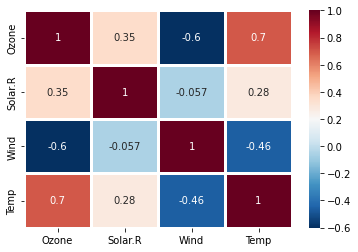

```python
sns.heatmap(air_cor,
           xticklabels = air_cor.columns,
           yticklabels = air_cor.columns,
           cmap = 'RdBu_r',
           annot = True,
           linewidth = 3)
```

### 산점도 행렬

두 개 이상의 변수가 있는 데이터에서 변수들 간의 산점도를 그린 그래프 여러 변수들 간의 산점도를 한 번에 볼 수 있도록 표현하여 변수들 간의 상관관계를 비교할 수 있음

> seabon.pariplot(data, hue=None, kind='scatter', dialog_kind='auto', markers=None, dropna=False, corner=True)
> - data: pandas.DataFrame
> - hue: 데이터의 범주형 변수, 집단을 색으로 구분해서 플롯을 그려줌
> - kind: 'scatter'(산점도), 'kde'(밀도그래프), 'hist'(히스토그램), 'reg'(회귀선)로 구성
> - diag_kind: 'auto', 'hist', 'kde', None으로 구성
> - markers: 마커 코드
> - cornder: True로 할 경우 세모 모양 상관계수 그래프 (디폴트는 False)

```python
iris = pd.read_csv('./data/iris.csv')
```

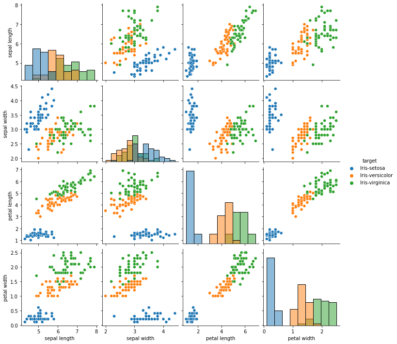

```python
# 범주형 변수의 범주에 따라 다른 색상으로 나타낼 수도 있음

sns.pairplot(iris, diag_kind='hist', hue='target')
plt.show()
```

## Profiling

- 어떠한 변수가 있는지 살펴본다.
- 이상치와 결측치에 관한 추가적인 탐색을 실시한다. (NaN 값은 어떻게 처리할지 등)
- 데이터의 개별 속성값을 관찰하면서, 예측한 범위와 분포인지, 아니라면 왜 아닌지 생각하고 분석한다.
- 데이터의 속성 간의 관계에 초점을 맞추어서 상관관게나 시각화 등 찾아내지 못했던 패턴을 발견해낸다.

```python
# jupyter 에서 아래 명령어 입력
#!conda update -n base -c defaults conda -y
#!conda install -c conda-forge pandas-profiling=2.8 -y
#!conda install -c conda-forge ipywidgetsy -y
#!conda install pandas=1.2 -y

# conda가 안된다면, pip를 사용
#!pip install -c conda-forge pandas-profiling=2.8
#!pip install conda-forge pandas-profiling=2.8
#!pip install pandas-profiling
```

```python
import pandas as pd
import numpy as np
```

```python
import pandas_profiling
```

```python
pd.__version__
```

```
'1.2.5'
```

```python
pandas_profiling.__version__
```

```
'2.8.0'
```

```python
iris = pd.read_csv('./data/iris.csv')
```

```python
from pandas_profiling import ProfileReport
ProfileReport(iris)
```

[interactive chart not shown]